# P4 Horario de Sueño

2/12/2021

# **Horario de sueño en el ciclo 2019-2 vs. 2021-1 de estudiantes de UTEC**

La sociedad actual es consciente del gran impacto que tiene el sueño sobre la vida de las personas. Los efectos del sueño no se limitan al propio organismo, sino que afectan el desarrollo y funcionamiento normal de un individuo en su vida cotidiana. La importancia de una buena calidad de sueño no solamente es fundamental como factor determinante de la salud, sino como elemento propiciador de una buena calidad de vida. Ello hace que sea fundamental estudiar la incidencia de estos horarios de sueño en diferentes situaciones, y cómo ha ido cambiando con la llegada de la educación virtual y el confinamiento.

## **2. Objetivos**

### **Objetivo General**

Analizar si el horario de sueño afecta el rendimiento académico de los alumnos, comparando entre la modalidad presencial y la modalidad virtual.

### **Objetivos específicos**

1. Evaluar el estado de sueño del público objetivo entre el 2019 y 2021, para poder compararlos.
2. Analizar si la pandemia tuvo un impacto en los horarios de sueño que tuvieron los alumnos en los años de estudio mencionados.
3. Determinar los cambios que tuvieron los alumnos en problemas físicos y mental en el periodo académico 2019 y compararlos con los cambios que tuvieron los alumnos en problemas físicos y mental en el periodo académico 2021.

## **3. Marco teórico**

- **Población objetivo**: Alumnos de UTEC que hayan ingresado entre los años 2016 a 2019, y que hayan estado matriculados en los ciclos 2019-2 y 2021-1.
- **Tipo de muestreo**: Muestreo aleatorio estratificado. El muestreo es estratificado debido a que muestra población objetivo es un subconjunto con la característica de haber ingresado en un rango de años en específico, ya que fuera de ese rango no podríamos contarlos para el estudio.
- **Sesgo**: Sesgo de selección. Nuestra muestra excluye una parte grande de la población total, que son los alumnos de UTEC ingresados durante 2020 y 2021, debido a que no han experimentado el contexto antes de la pandemia, que incluía un desplazamiento hasta el campus, y por ende habría que preparar un sistema de recolección de datos adicional.
- **Unidades muestrales**: 155 encuestados
- **Interesados**
  - El área de Bienestar estudiantil: Conocer la realidad de los estudiantes en este ciclo virtual, para poder brindar herramientas de ayuda psicológica de manera más efectiva a los estudiantes.
  - El área directiva: Conocer si la virtualidad en comparación a las clases presenciales ha afectado o no el rendimiento académico de los estudiantes y brindar herramientas académicas a los estudiantes.
  - La comunidad estudiantil: Aunque los estudiantes son los que participan de este estudio, algunos no conocen por completo en cómo el sueño les puede afectar en sus actividades académicas y personales, por lo que con el estudio les damos a conocer los posibles riesgos de no dormir bien.

## **4. Limpieza de datos**

### **Base de datos “Horario de sueño”**

Nosotros al crear las preguntas pusimos todas las alternativas posibles que puedan tener las personas al momento de rellenar nuestra encuesta y estas alternativas nos son útil para la investigación. Asimismo, todas nuestras preguntas fueron obligatorias, por lo que no tenemos ningún NA.

## **5. Correcciones de la entrega anterior**

En el informe de la entrega P3, hubo una falta de profundidad en el uso de descriptores numéricos la cual ya fue debidamente modificada y se mejoro la ortografía, aparte de aumentar la seccion de regresión

## **6. Descriptores apropiados para cada variable**

### **Variable “Cantidad de horas de sueño 2019-2”:**

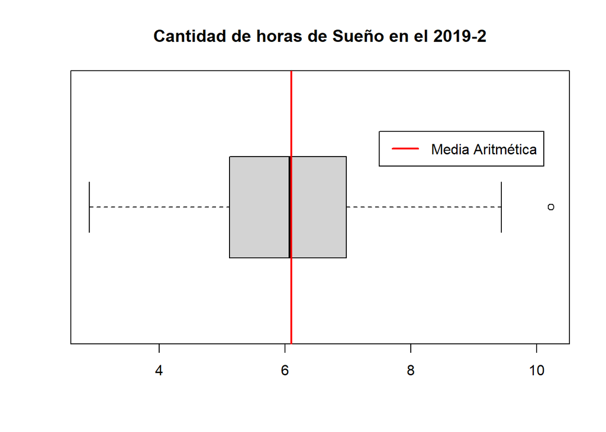

Resumen del Boxplot de Horas de sueño 2019-2

```r
ResHo2019
```

```
##    Min. 1st Qu.  Median    Mean 3rd Qu.    Max.
##   2.890   5.120   6.080   6.099   6.980  10.230
```

Moda de la variable Horas de sueño 2019-2

```r
mfv(x)
```

```
## [1] 6.40 6.48 6.68
```

JUSTIFICACIÓN: Hacemos el uso del gráfico boxplot, porque distribuye de manera eficiente y nos indica la media con más precisión, indicándonos hacia donde está sesgado respecto a la mediana. De esta manera, podemos ver un aproximado la cantidad de estudiantes que solía descansar la cantidad de horas recomendadas para un estudiante en el 2019-2.

### **Variable “Promedio académico 2019-2”:**

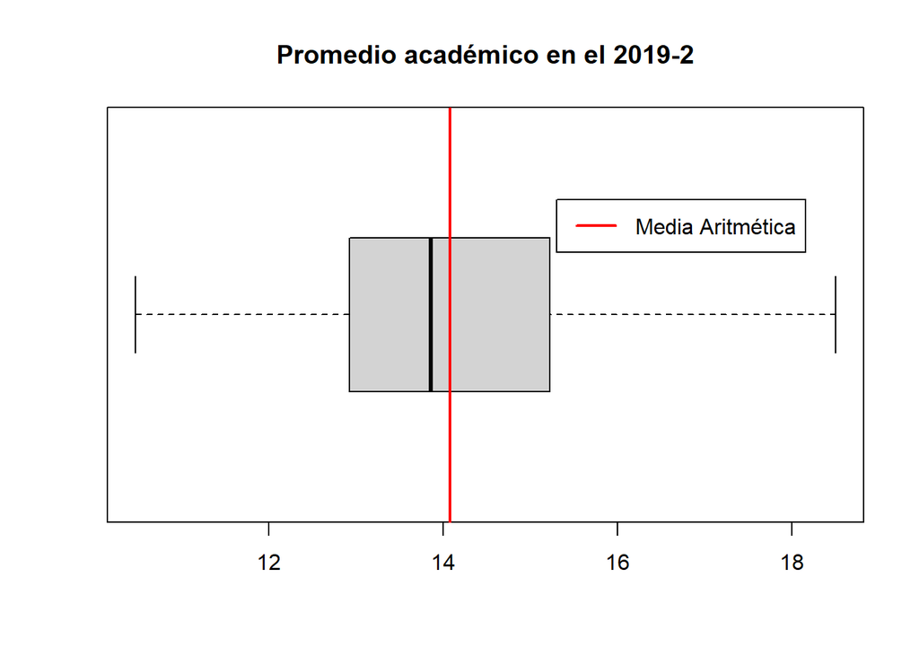

Resumen del Boxplot de “Promedio académico 2019-2”

```r
ResProm2019
```

```
##    Min. 1st Qu.  Median    Mean 3rd Qu.    Max.
##   10.47   12.93   13.86   14.08   15.22   18.50
```

Moda de la variable “Promedio académico 2019-2”

```r
mfv(y)
```

```
## [1] 12.56 12.97 13.06 13.31 14.66
```

En el gráfico generado por el boxplot se puede apreciar que la la cantidad promedio se concentra entre 12.93 y 15.22 que son el primer y el tercer cuartil respectivamente, quienes nos ayudan a ver la concentración de promedios y de esta manera hallar la mediana y la mediana sabiendo de esta manera a que lado está sesgado. Como se puede observar en esta gráfica la media está sesgada hacia la derecha.

JUSTIFICACIÓN: Se usa la gráfica boxplot, porque distribuye de manera eficiente y nos indica la media con más precisión, indicándonos hacia donde está sesgado respecto a la mediana. De esta manera, podemos ver un aproximado la cantidad de estudiantes que tenían un buen promedio en el 2019-2.

## **PERIODO ACADÉMICO 2021-1**

### **Variable “Cantidad de horas de sueño 2021-1”:**

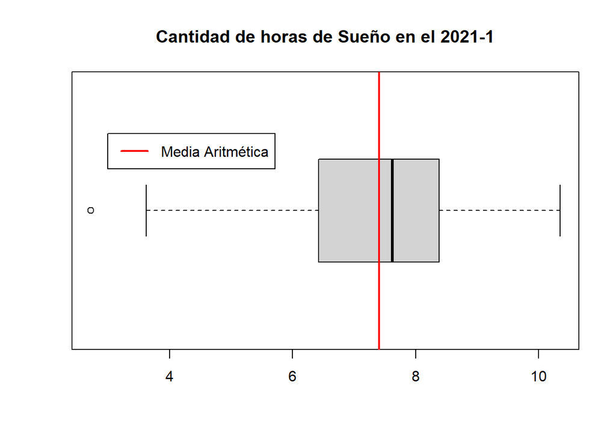

Resumen del Boxplot de Horas de sueño 2021-1

```r
ResHo21
```

```
##    Min. 1st Qu.  Median    Mean 3rd Qu.    Max.
##   2.720   6.425   7.620   7.408   8.385  10.350
```

Moda de la variable Horas de sueño 2021-1

```r
mfv(z)
```

```
## [1] 5.75 7.36 7.74 8.22 8.45
```

El gráfico no muestra en qué intervalo se concentra las horas que solían dormir los estudiantes en el 2021, el cual muestra un intervalo de 6.43 a 8.39, que viene a ser el primer y tercer cuartil pero que tenemos un mínimo y un máximo en las cuales que se concentran en menos proporción y un valor atípico, de aquí podemos observar también que la media está sesgada hacia la izquierda de la mediana dando a conocer que el promedio de alumnos dormían 7 horas aproximadamente, el cual nos muestra que los alumnos al tener la modalidad virtual descansan más respecto a un alumno de modalidad presencial.

JUSTIFICACIÓN: Empleamos la gráfica boxplot, porque distribuye de manera más eficiente y nos indica la media con más precisión, indicándonos hacia donde está sesgado respecto a la mediana. De esta manera, podemos ver un aproximado la cantidad de estudiantes que solía descansar la cantidad de horas recomendadas para un estudiante el periodo académico 2021-1.

### **Variable “Promedio académico en el 2021-1”:**

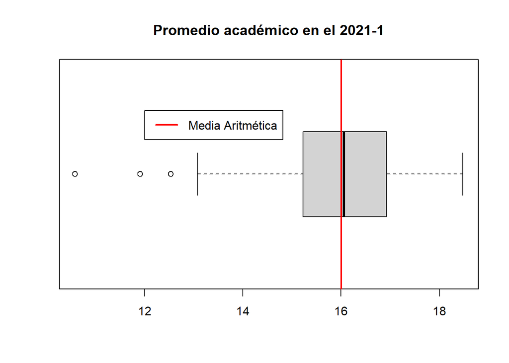

Resumen del Boxplot de “Promedio académico 2021-1”

```r
ResProm21
```

```
##    Min. 1st Qu.  Median    Mean 3rd Qu.    Max.
##   10.58   15.22   16.06   16.01   16.92   18.48
```

Moda de la variable “Promedio académico 2021-1”

```r
mfv(f)
```

```
## [1] 15.9
```

En el gráfico generado por el boxplot se puede apreciar que la la cantidad promedio se concentra entre 15.22 y 16.92 que son el primer y el tercer cuartil respectivamente, quienes nos ayudan a ver la concentración de promedios y de esta manera hallar la distribución de la mediana y la mediana, sabiendo de esta manera a que lado está sesgado. Como se puede observar en esta gráfica la media está sesgada ligeramente a la izquierda, dándonos a conocer que los alumnos tienen un buen promedio en la modalidad virtual respecto al promedio alcanzado por los alumnos de modalidad presencial.

JUSTIFICACIÓN: Usamos la gráfica boxplot, porque distribuye de manera más eficiente y nos indica la media con más precisión, indicándonos hacia donde está sesgado respecto a la mediana. De esta manera, podemos ver un aproximado la cantidad de estudiantes que tenían un buen promedio en el 2021.

## **7. Relaciones entre variables**

### **Variable “Promedio académico 2019-2” vs. Variable “Problemas de salud mental 2019-2”:**

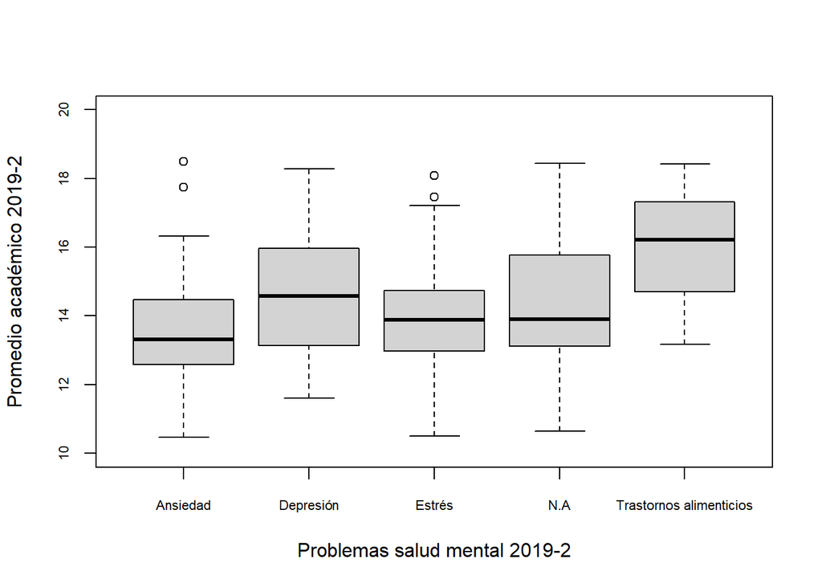

En este gráfico de boxplots hemos planteado la influencia de la variable categórica de “problemas de salud mental reportados” sobre la variable numérica “promedio académico” durante el ciclo 2019-2. Hemos graficado a la salud mental como la variable independiente ya que consideramos que la salud mental del alumno es también un factor determinante en el rendimiento académico del ciclo. Podemos determinar que en el caso de los alumnos que se quejaron de tener ansiedad, presentan en su mayoría el promedio académico más bajo, con un promedio ligeramente por arriba de 13, y con los percentiles extremos hasta una nota menor a 11, y menor que 17. Si bien la mayoría de promedios se colocan alrededor de 14, también es el que abarca los resultados más variados, con los bigotes yendo también con notas menores a 10.5, pero alcanzando notas por encima de 17. También, a pesar de que los trastornos alimenticios parecen no afectar en los promedios, cabe resaltar que hubieron menos de 5 reportes de esta complicación. La depresión es la que menos parece afectar con una mayoría de promedios alrededor del promedio de nota 14, y el bigote inferior arriba de 11. Se puede sugerir que si existe un efecto en el promedio debido a las complicaciones en la salud mental, al revisar los promedios de aquellos que no reportaron, ya que el percentil superior logró calificaciones muy altas.

JUSTIFICACIÓN: Escogimos este descriptor gráfico, para mostrar la relación entre una variable numérica (Promedio Académico 2019-2) y una variable categórica (Problemas de salud mental 2019–2). Al mostrar el “boxplot” en una escala común, nos ayuda a observar con mayor facilidad la relación que pudiera existir entre estas dos variables.

### **Variable “Promedio académico 2021-1” vs Variable “Problemas de salud mental”:**

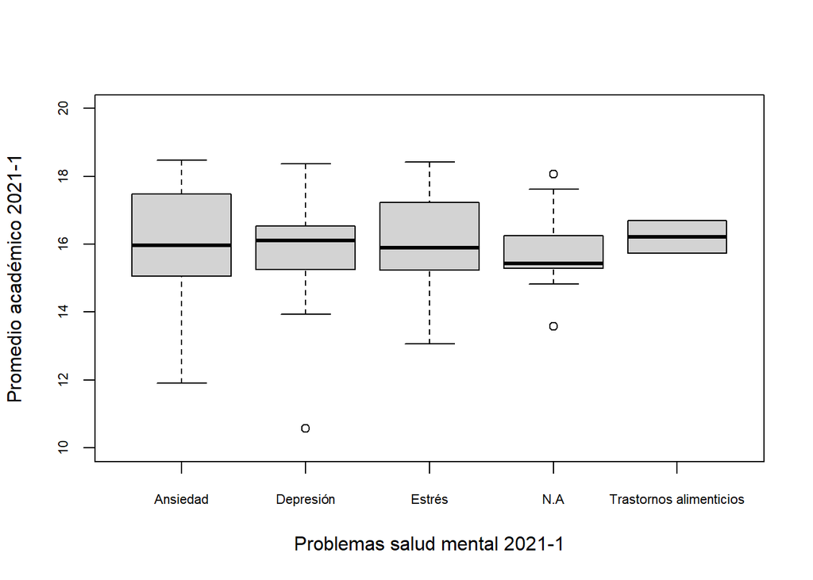

En este gráfico de boxplots hemos planteado la influencia de la variable categórica de “problemas de salud mental reportados” sobre la variable numérica “promedio académico” durante el ciclo 2021-1. Hemos graficado a la salud mental como la variable independiente ya que consideramos que la salud mental del alumno es también un factor determinante en el rendimiento académico del ciclo. A pesar del alto número de reportes de depresión por parte de los alumnos, este parece no tener efecto alguno sobre el promedio académico, al encontrarse la mayoría de promedios obtenidos alrededor de 16, y el bigote inferior por encima de 13, lo cual son promedios competitivos al nivel universitario. Teniendo menos de 12 reportes combinados entre aquellos que presentaron trastornos alimenticios y ninguna complicación mental, no se consideran relevantes para el estudio, solo por el hecho de que la pandemia provocó un gran incremento en problemas de salud mental. La ansiedad es la única complicación que parece provocar un menor rendimiento académico, por el hecho de que el bigote inferior se encuentra alrededor de la nota 12, sin embargo la mayoría de promedios ronda la nota 16, por lo que se puede sugerir que durante la pandemia las complicaciones en la salud mental no provocaron un menor rendimiento académico.

JUSTIFICACIÓN: Escogimos este descriptor gráfico, para mostrar la relación entre una variable numérica (Promedio Académico 2021-1) y una variable categórica (Problemas de salud mental 2021-1). Al mostrar el “boxplot” en una escala común, nos ayuda a observar con mayor facilidad la relación que pudiera existir entre estas dos variables.

## **8. Observaciones relevantes del comportamiento de las variables**

### **Variable “Horas de sueño 2019-2” vs Variable “Horas de sueño 2021-1”**

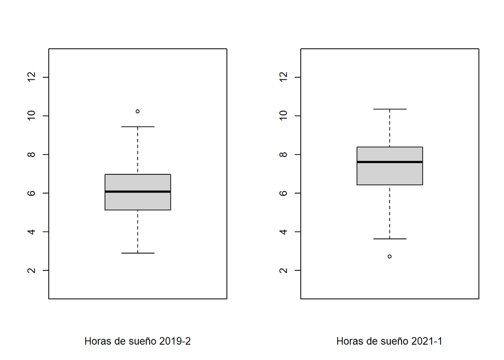

En el siguiente gráfico de boxplots podemos observar las variaciones de horas de sueño dormidas durante el ciclo 2019-2 y el ciclo 2021-1. A simple vista se puede determinar que 2021 y la modalidad virtual han mostrado un incremento de las horas de sueño dormidas, que se puede constatar con las medianas mostradas, siendo el promedio de horas dormidas en 2019 cercano a 6 horas, y el promedio en 2021 por encima de las 7 horas y media. Mientras que el bigote inferior del gráfico perteneciente a 2019 desciende por debajo de las 3 horas de sueño, una cantidad bastante lejos de ser sana, el bigote inferior del gráfico de 2021 se ubica por encima de las 3 horas, si bien no algo óptimo, igual demuestra la mejora entre ambos contextos. El hecho de ya no necesitar trasladarse a la universidad para poder asistir a las clases a tiempo resulta en el aumento de horas de sueño durante 2021, aunque como se puede ver en otras comparaciones, no necesariamente resulta en algo positivo.

JUSTIFICACIÓN: Se utilizó este descriptor gráfico para poder comparar 2 variables numéricas que vienen determinadas por 2 periodos de tiempo diferentes, para apreciar con descriptores numéricos concisos cuáles son las similitudes y la evolución de un período respecto al otro.

### **Variable “Promedio académico 2019-2” vs. Variable “Promedio académica 2021-1”:**

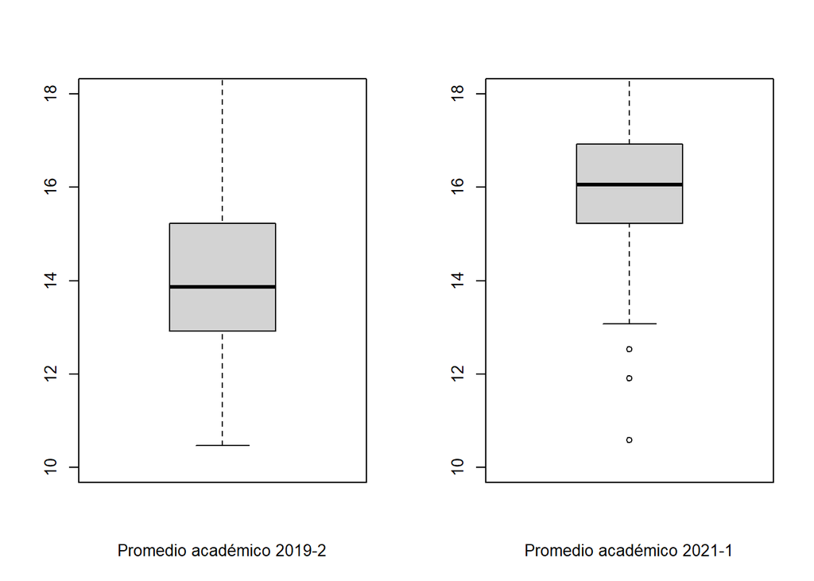

```r
mat <- matrix(c(1, 2),
              nrow = 2, ncol = 2,
              byrow = TRUE)

layout(mat = mat)

set.seed(6)
boxplot(DF$prom19, xlab = "Promedio académico 2019-2", ylim=c(10,18))
boxplot(DF$prom21, xlab = "Promedio académico 2021-1", ylim=c(10,18))
```

En el siguiente gráfico de boxplots podemos observar las variaciones de los promedios académicos obtenidos durante el ciclo 2019-2 y el ciclo 2021-1. Se puede evidenciar claramente el aumento de las notas obtenidas durante los alumnos durante el ciclo virtual respecto al ciclo presencial, incluidos los mínimos y demás. Mientras que en 2019 la mayoría de alumnos obtuvo promedios cercanos al 14, en 2021 la mayoría crecieron hasta por arriba de la nota 16, demostrando la mejora académica. Si bien ambos bigotes superiores llegan a sobrepasar las notas de 18, en el caso de los bigotes inferiores también se identifica la mejora durante el proceso virtual al tener el bigote inferior ubicado alrededor de la nota 13, mientras que durante 2019 este alcanzaba notas por debajo de 11. Este aumento de las notas, si bien se podría deber al aumento de horas de sueño de los alumnos, también podría tener otros factores involucrados.

JUSTIFICACIÓN: Se utilizó este descriptor gráfico para poder comparar 2 variables numéricas que vienen determinadas por 2 periodos de tiempo diferentes, para apreciar con descriptores numéricos concisos cuáles son las similitudes y la evolución de un período respecto al otro.

### **Variables “Créditos / Horas de sueño 2019-2” vs Variable “Créditos / Horas de sueño 2021-1”:**

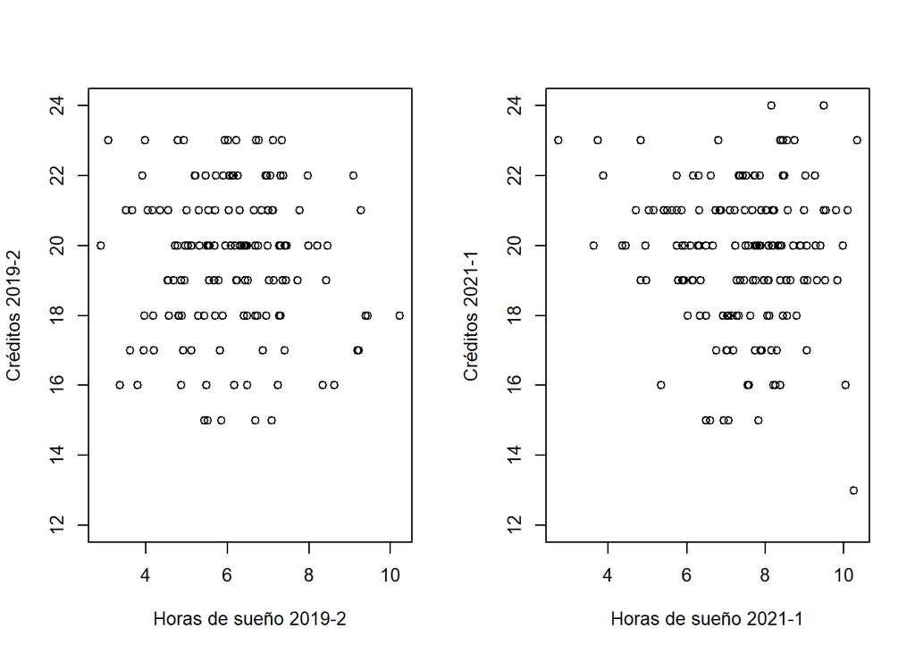

```r
mat <- matrix(c(1, 2),
              nrow = 2, ncol = 2,
              byrow = TRUE)

layout(mat = mat)

set.seed(6)
plot(DF$cred19 ~ DF$horassueno19, ylab = "Créditos 2019-2", xlab = "Horas de sueño 2019-2", ylim=c(12,24))
plot(DF$cred21 ~ DF$horassueno21, ylab = "Créditos 2021-1", xlab = "Horas de sueño 2021-1", ylim=c(12,24))
```

Como podemos observar en ambos gráficos de dispersión, para ambos casos el valor de 20 créditos muestra una ligera preferencia en comparación con el resto de los valores para la variable de créditos académicos en el año 2019. Sin embargo en el año 2021, se evidencian valores atípicos de 24 créditos, los cuales se pueden deber al hecho de que los estudiantes les resulte más sencillo llevar más créditos académicos puesto a que los estudiantes pueden haber encontrado una ventaja de estudiar desde casa y es el poder aprovechar el tiempo al máximo ya sea teniendo un mejor descanso o estudiando para la cantidad de créditos.

JUSTIFICACIÓN: Escogimos este descriptor gráfico porque queríamos observar de que manera estaban dispersos los datos en ambos periodos de tiempo, para de esta manera poder hacer un mejor análisis de la relación que guardan ambos años

### **Variable “Promedio académico/Horas de sueño 2019-2” vs. Variable “Promedio académico/Horas de sueño 2021-1”:**

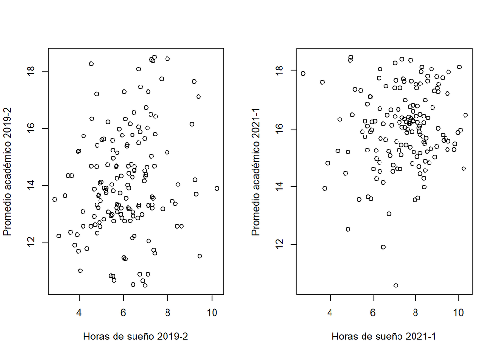

Comparando las dos gráficas, notamos levemente un patrón que inclina la densidad de dispersión hacia menos horas de sueño (4 a 6 horas) y menos promedio académico (12 a 15) en el 2019, siendo el caso contrario en el 2021 que encontramos la densidad de horas de sueño de 7 a 10 horas con un promedio de 15 a 18. Esto se explicaría a que debido a la falta de sueño la mente no rinde de la misma manera que una persona que si duerme la cantidad de horas necesaria, expresándose en la nota de su promedio académico.

JUSTIFICACIÓN: Escogimos este descriptor gráfico porque queríamos observar de que manera estaban dispersos los datos en ambos periodos de tiempo, para de esta manera poder hacer un mejor análisis de la relación que guardan ambos años y evaluar la tendencia de la dispersión.

## **9. Preguntas inferenciales**

### 1. ¿El Promedio de horas de sueño ha cambiado con la pandemia por COVID-19?

Se sabe que producto de la pandemia se estableció una cuarentena a nivel nacional, lo que ocasionó que las clases se dictaran de manera remota. Esto produjo cambios en los horarios de los estudiantes que asistían a la universidad en el 2019, puesto a que el tiempo que dedicaban a movilizarse para llegar temprano a las clases ahora lo pueden dedicar a dormir o a realizar otras actividades.

$\text{Hipótesis nula: la cantidad de horas de sueño es mayor igual que 7.4 en el 2019-1}\\$ $\text{Hipótesis alternativo: la cantidad de horas de sueño es menor que 7.4 en el 2019-1} \\$

$\\H_0:\mu\geq7.4\\$

$\\H_1:\mu<7.4$

```
## Promedio de la variable horas de sueño en el 2019: 6.1
```

```
## desviacion estandar de las horas de sueño en el 2019: 1.38
```

```
## numero de muestras: 155
```

Sabiendo la desviación estándar, el promedio de la muestra y el número de muestra hallamos el intervalo de confianza y nuestro nivel de confianza de 95% hallamos nuestro t.

$S=\sqrt{\frac{n}{n-1}}\sigma\\[1.5 cm]\\$

$t=\frac{\overline{X}-\mu_0}{\frac{S}{\sqrt{n}}}$

```
## [1] -11.69
```

```
## [1] 0
```

```
## [1] -1.96
```

```
## [1] 5.88
```

```
## [1] 6.32
```

Haciendo prueba de cola inferior podemos rechazar o validar la hipótesis.

```
## [1] -11.73
```

```
## [1] -1.96
```

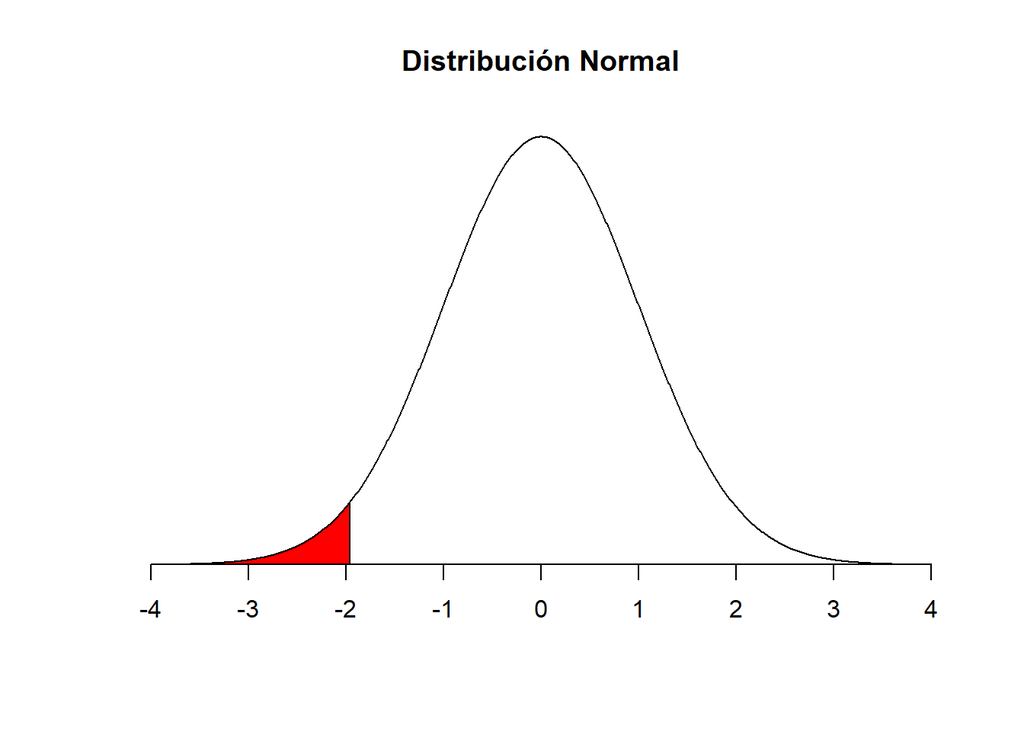

Una ves obtenido los resultados podemos rechazar la hipótesis por se hallo el t < tcritico y el p_valor menor a nuestro alpha ya que tampoco se encuentra en el intervalo de confianza.

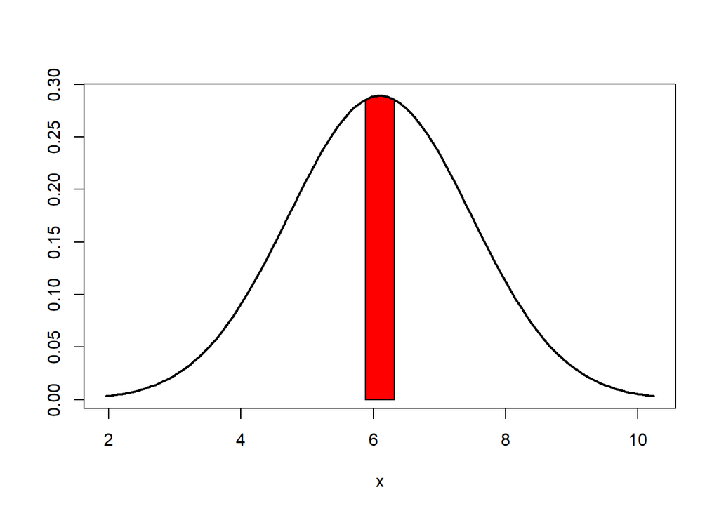

$\text{Hipótesis nula: la cantidad de horas de sueño mayor iagual a 6.1 en el 2021-1}\\$ $\text{Hipótesis alternativo:la cantidad de horas de sueño es menor que 6.1 en el 2021-1} \\$

$\\H_0:\mu\geq6.1\\$

$\\H_1:\mu<6.1$

```
## Promedio de la variable horas de sueño en el 2021: 7.41
```

```
## desviacion estandar de horas de sueño en el 2021: 1.46
```

```
## numero de muestras: 155
```

Sabiendo la desviación estándar, el promedio de la muestra y el número de muestra hallamos el intervalo de confianza y nuestro nivel de confianza de 95%.

```
## [1] 1.464733
```

```
## [1] 11.13
```

```
## p_valor:  1
```

```
## [1] 1.96
```

```
## [1] 7.18
```

```
## [1] 7.64
```

[output not shown]

Se acepta la hipótesis nula, porque la cantidad de horas ya que cumple con lo planteado que es mayor a 6.1 ya que el p-valor sale mayor a los 0.05.

Se concluye que el promedio de horas de sueño del periodo académico del 2021-1 aumentó respecto al promedio de horas de sueño del periodo 2019-2.

### 2. ¿El promedio académico ha cambiado con la pandemia por COVID-19?

Como explicamos en la pregunta anterior, debido a que las clases se realizan de manera remota, los alumnos podían aprovechar de otras maneras el tiempo que utilizaban para transportarse y otras necesidades de la modalidad presencial. Por lo que si dedican ese tiempo a estudiar, es posible de que su promedio haya cambiado.

$\\H_0:\mu\geq16.1\\$

$\\H_1:\mu<16.1$

```
## Promedio de la variable promedio académico en el 2019: 14.08
```

```
## desviacion estandar promedio académico en el 2019: 1.83
```

```
## numero de muestras: 155
```

Sabiendo la desviación estándar, el promedio de la muestra y el número de muestra hallamos el intervalo de confianza y nuestro nivel de confianza de 95%.

```
## [1] 1.835932
```

[output not shown]

```
## p_valor:  0
```

```
## [1] -1.96
```

```
## [1] 13.79
```

```
## [1] 14.37
```

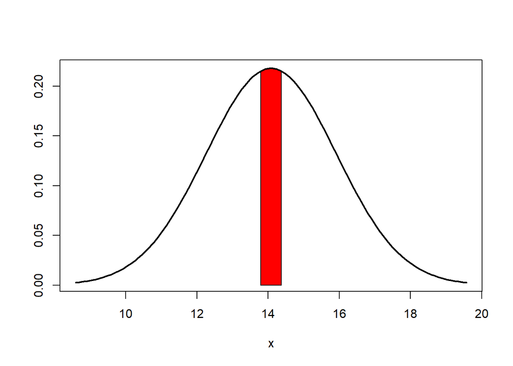

La hipótesis planteada se se rechaza ya que el promedio planteado supera el intervalo por otro lado el p valor sale menor a t critico, también el t< t critico.

$\text{Hipótesis nula: El promedio académico es mayor iagual a 14 en el 2021-1}\\$ $\text{Hipótesis alternativo:El promedio académico es menor que 14 en el 2021-1} \\$

$\\H_0:\mu\geq14\\$

$\\H_1:\mu<14$

```
## Promedio de la variable promedio académico en el 2021: 16.01
```

```
## desviacion estandar promedio académico en el 2021: 1.36
```

```
## numero de muestras: 155
```

Sabiendo la desviación estándar, el promedio de la muestra y el número de muestra hallamos el intervalo de confianza y nuestro nivel de confianza de 95%.

```
## [1] 1.364408
```

[output not shown]

```
## p_valor:  0
```

```
## [1] -1.96
```

```
## [1] 15.8
```

```
## [1] 16.22
```

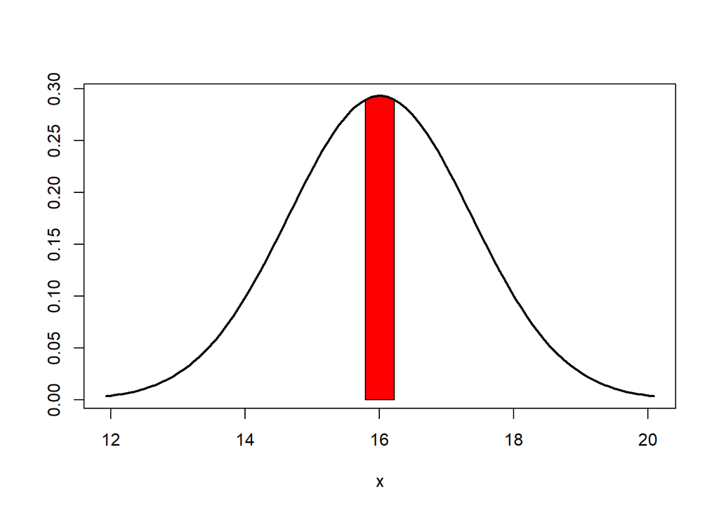

Se aprueba la hipótesis nula,aun que no se los resultados nos dicen que no pero cumple en ser mayor a 14 ya el valor inferior del intervalo de confianza es mayor a 15.8.

Se concluye que el promedio académico de los alumnos del periodo 2021-1 aumentó respecto al promedio que tenían los alumnos en el periodo 2019-2.

# **10. Regresión de las variables**

## **Distribución normal**

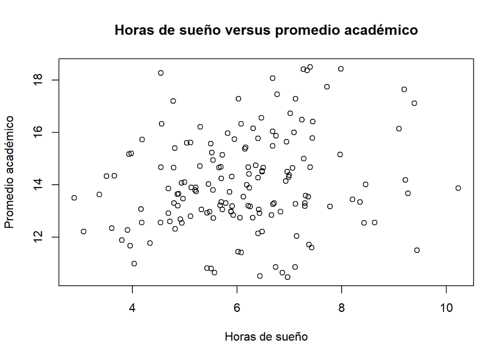

## **Distribución con intervalos aplicados**

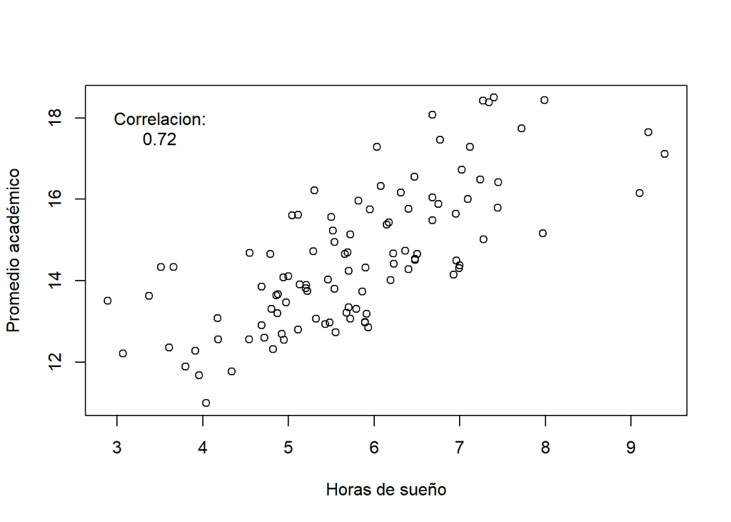

## **Distribución con intervalos aplicados**

```
##
## Call:
## lm(formula = TD4$prom19 ~ TD4$horassueno19)
##
## Residuals:
##     Min      1Q  Median      3Q     Max
## -1.8795 -0.9580 -0.2001  0.7128  2.6511
##
## Coefficients:
##                  Estimate Std. Error t value Pr(>|t|)
## (Intercept)       8.95283    0.54433   16.45   <2e-16 ***
## TD4$horassueno19  0.96947    0.09203   10.53   <2e-16 ***
## ---
## Signif. codes:  0 '***' 0.001 '**' 0.01 '*' 0.05 '.' 0.1 ' ' 1
##
## Residual standard error: 1.177 on 102 degrees of freedom
## Multiple R-squared:  0.5211, Adjusted R-squared:  0.5164
## F-statistic:   111 on 1 and 102 DF,  p-value: < 2.2e-16
```

## **Ecuación de la regresión**

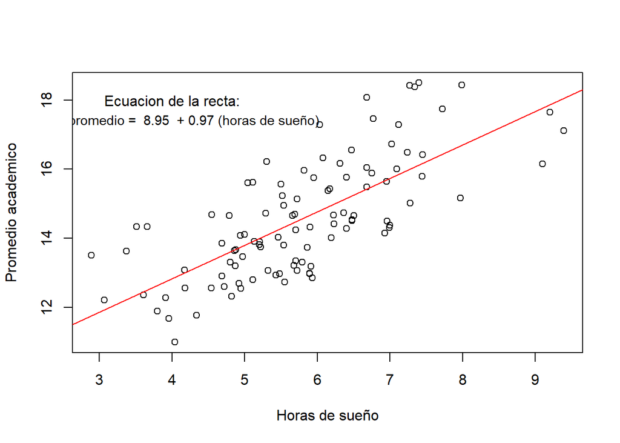

# **11. Reflexiones y conclusiones**

## **¿Qué aprendimos?**

Luego de haber concluido cada etapa del proyecto, hemos aprendido diversas herramientas estadísticas para poder interpretar y comprender de una manera más óptima la información que se recibe, al conocer de donde se obtienen las cifras y datos que recibimos de los medios en el día a día, y en el trabajo de campo en un futuro cercano. Nuestro mayor aprendizaje respecto a la realización del proyecto se dió a una mejor planificación previa sobre las varaibles y la información relevante al estudio que podíamos obtener de ellas